# Demo: a life-cycle model with one random shock on consumption

Using `src.jl` and `Household.jl`. Please read the academic [documentation](https://clpr.github.io/pages/blogs/190622_The_household_life_cycle_problem_with_a_continuous_medical_expenditure_shock.html) for details.

```julia
# julia 1.1
    push!(LOAD_PATH,pwd()) # add current working directory to search paths
    import Household # solvers of the household problem
    import src # useful tools, used to prepare data
```

```
┌ Info: Recompiling stale cache file C:\Users\Lenovo\.julia\compiled\v1.1\Household.ji for Household [top-level]
└ @ Base loading.jl:1184
```

## Part 1: $v_{1}\sim\pi_{\mathbb{v}}$, corresponding to Section 4 in the documentation (analytical solution without borrowing constraint)

First, we construct a common scenario for some variables: $$ \begin{cases} A_s \equiv 0.99, s=1,\dots,S-1 \\ A_S = 1.0, s=S \\ B_s \equiv (1+r) = 1.05 \\ F_s = (1-\sigma)w = 0.7, s=1,\dots,20 \\ F_s = 0, s=21,\dots,S \\ S = 40 \end{cases} $$ Then, we define $\dot{E}_s$ as the Section 5.1 in our academic documentation: $$ \dot{E}_s = (1+\mu_s)[ 1 + I(v_s)\cdot \text{cp}_s \cdot v_s + (1-I(v_s))\cdot v_s ], s= 1,\dots,S $$ where $\mu_s\equiv 0.13, \text{cp}_s\equiv 0.3$ are exogenous parameters, $v_s$ is a random variable following an AR(1) process $ \ln{v_{s+1}} = (1-\rho)m + \rho\ln{v_{s}} + \epsilon_s, \epsilon\sim \text{i.i.d. }N(0,\sigma_\epsilon) $. Please note that we let $A_S=1$ because **all** agents quit the economy at time $S+1$. In some ways, they all live through year $S$.

Assuming that we have estimated $\rho=0.95,m=-2.659$ and $\sigma_\epsilon=0.05$ from data.

With $ \dot{f}(v_s) = [ I(v_s)\cdot \text{cp}_s + (1-I(v_s))\cdot ] v_s $, the next thing to do is to computing the expectation of $\dot{E}(v_s)$. It consists of:

1. Discretizing the AR(1) process of $v_s$ with a discrete Markov Chain
2. Computing $\mathbb{E}[\dot{f}(v_s)]$
3. Computing $\mathbb{E}[\dot{E}(v_s)]$ with $\mathbb{E}[\dot{f}(v_s)]$

```julia
S = 40 # maximum number of periods

# DISCRETIZING AR(1) PROCESS
# 1. get an AR(1) instance
vProcess = src.DiscreteTimeAR1( 0.95, 0.05, Z̄ = -2.659 )
# 2. using (Tauchen, 1986) algorithm to do discretization
vMC = src.approx_ar1(vProcess)
# 3. get the stationary distribution of vMC
π_vMC = src.stationary_distribution(vMC)
# 4. make ln(v_s) to v_s (changing the states of vMC)
vMC.w = exp.(vMC.w)
# display the results
println("The approximating Markov Chain is: ", vMC.w )
# println("With a transition matrix: ", vMC.P )
println("Its stationary distribution is: ", π_vMC )
```

```
The approximating Markov Chain is: [0.0433094, 0.048836, 0.0550677, 0.0620946, 0.0700182, 0.0789529, 0.0890277, 0.100388, 0.113198]
Its stationary distribution is: [0.0107831, 0.0427704, 0.114414, 0.206406, 0.251253, 0.206406, 0.114414, 0.0427704, 0.0107831]
```

Assuming $\text{cp}_s\equiv 0.3$, and the threshold $\underline{v} = 0.08$, we can compute $\mathbb{E}[\dot{f}(v_s)]$:

```julia
cp = fill(0.3, S)
tmpidx = (vMC.w .< 0.08, vMC.w .>= 0.08 )::Tuple
𝔼f = sum( vMC.w[tmpidx[1]] .* π_vMC[tmpidx[1]] ) .+ cp .* sum( vMC.w[tmpidx[2]] .* π_vMC[tmpidx[2]] )
println("𝔼f is a ", typeof(𝔼f), " whose length is ", length(𝔼f))
println(𝔼f)
# ------------------
𝔼E = (1 + 0.13) .* ( 1 .+ 𝔼f )
println("𝔼f is: "); println(𝔼E)
```

```
𝔼f is a Array{Float64,1} whose length is 40
[0.0602717, 0.0602717, 0.0602717, 0.0602717, 0.0602717, 0.0602717, 0.0602717, 0.0602717, 0.0602717, 0.0602717, 0.0602717, 0.0602717, 0.0602717, 0.0602717, 0.0602717, 0.0602717, 0.0602717, 0.0602717, 0.0602717, 0.0602717, 0.0602717, 0.0602717, 0.0602717, 0.0602717, 0.0602717, 0.0602717, 0.0602717, 0.…
𝔼f is:
[1.19811, 1.19811, 1.19811, 1.19811, 1.19811, 1.19811, 1.19811, 1.19811, 1.19811, 1.19811, 1.19811, 1.19811, 1.19811, 1.19811, 1.19811, 1.19811, 1.19811, 1.19811, 1.19811, 1.19811, 1.19811, 1.19811, 1.19811, 1.19811, 1.19811, 1.19811, 1.19811, 1.19811, 1.19811, 1.19811, 1.19811, 1.19811, 1.19811, 1.…
```

Now, let's prepare a data package and put it into our solver.

```julia
dat = Household.LifeCycleDatPkg(
    cat(fill(0.99,S-1),[1.0,],dims=1), # As
    fill(1.05,S), # Bs
    𝔼E,
    cat(fill(0.7,20),zeros(S-20),dims=1), # Fs
    a1 = 0.0, β = 0.99, γ = 1.5, S = S
)
# let's solve it
@time res = Household.solve(dat)
```

```
[1.0, 0.929429, 0.863838, 0.802875, 0.746215, 0.693554, 0.644609, 0.599118, 0.556837, 0.517541, 0.481017, 0.447071, 0.415521, 0.386197, 0.358942, 0.333611, 0.310068, 0.288186, 0.267848, 0.248946, 0.231377, 0.215049, 0.199873, 0.185767, 0.172657, 0.160473, 0.149148, 0.138622, 0.12884, 0.119747, 0.111…
  0.004892 seconds (1.33 k allocations: 52.328 KiB)
```

```
(a = [0.0, -0.356983, -0.660509, -0.912638, -1.11518, -1.26971, -1.37757, -1.43989, -1.45758, -1.43135  …  0.661684, 0.58336, 0.508647, 0.437174, 0.368589, 0.302557, 0.238759, 0.176891, 0.116661, 0.0577877], c = [0.879231, 0.817182, 0.759513, 0.705913, 0.656096, 0.609794, 0.56676, 0.526763, 0.489589…
```

Finally, we do some simple visualization

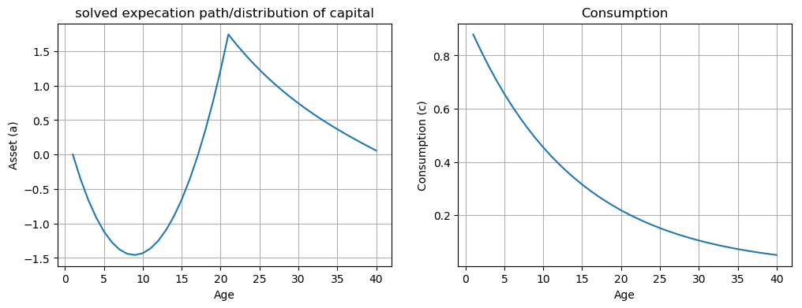

```julia
using PyPlot

figure(figsize=(12,4));
subplot(1,2,1)
    plot(1:S,res.a); grid(true); title("solved expecation path/distribution of capital"); xlabel("Age"); ylabel("Asset (a)")
subplot(1,2,2)
    plot(1:S,res.c); grid(true); title("Consumption"); xlabel("Age"); ylabel("Consumption (c)");
```

In the above two figures, we can see that households borrow money to consume in the first 16~17 years, then begin to do savings. Their asset becomes exact zero when age is 41 (not plotted but obvious). The underlying assumption is that there is a perfect annuity market in which younger generations are able to borrow money from elder generations without transaction cost (i.e. no friction). This case is quite common in theoretical analysis. But there is one important disadvantage: **this method cannot handle the case with borrowing limit(s).**

## Part 2: $v_{1}\sim\pi_{\mathbb{v}}$ corresponding to Section 5.2 in the documentation (deterministic Dynamic Programming with borrowing constraint)

So, if there is a borrowing constraint, e.g. $a_s\geq 0$ for all $s$, how to solve this life-cycle problem? Section 5.2 in our [academic documentation](https://clpr.github.io/pages/blogs/190622_The_household_life_cycle_problem_with_a_continuous_medical_expenditure_shock.html) (please carefully read it before trying to understand this demo) discusses this topic. A main conclusion is: **if the initial distribution follows the stationary distribution of the discretized Markov Chain, then this stochastic life-cycle model is equivalent to a deterministic dynamic programming problem**. This part is a demo to show how to use our standard solver provided in `Household.jl` to solve a deterministic Dynamic Programming problem which can be denoted as the following Bellman equation: $$ \begin{aligned} V_s(a_s) &= \max_{c_s\geq0} \mathbb{E}\Big{[} u(c_s) + \beta V_{s+1}(k_{s+1}|v_{s}) \Big{]} \\ \text{s.t.}&\begin{cases} a_s\in[\underline{a},\bar{a}],s=1,\dots,S \\ A_{s} a_{s+1} = B_{s} a_{s} - E_{s} c_s + F_s \\ a_1 \in R^+ \\ a_{S+1} = 0 \\ S\geq 2 \\ \end{cases} \end{aligned} $$ Here because $\mathbb{E}[\dot{E}_s(v_s)]$ is period-independent, we write it as $E_{s}$ for generality.

This solver is developed based on the Gauss programs in [(Heer & Mausser, 2015)](https://www.wiwi.uni-augsburg.de/en/vwl/maussner/chair/maussner/).

We still use the data pacakge `dat` defined above, to display the difference between no-borrowing-constraint and with-borrowing-constraint.

```
  1.278167 seconds (13.07 M allocations: 862.124 MiB, 5.85% gc time)
  4.395234 seconds (40.45 M allocations: 4.445 GiB, 7.16% gc time)
 43.451123 seconds (205.55 M allocations: 47.287 GiB, 16.96% gc time)
```

[figure not shown]

```
235.894573 seconds (779.64 M allocations: 330.534 GiB, 18.76% gc time)
```

```
PyObject <matplotlib.legend.Legend object at 0x0000000033A2AE48>
```

```julia
gridnums = [100,200,500,1000]
figure(figsize=(12,4)); # new a blank figure
for tmp_gridnum in gridnums
    @time res = Household.solve_dp(dat, gridnum = tmp_gridnum) # solve and print the time cost
    subplot(1,2,1); plot(res.a)
    subplot(1,2,2); plot(res.c)
end # for
# add title, labels etc.
subplot(1,2,1); title("optimal asset paths at different griding search level"); xlabel("Age"); grid(true); ylabel("Asset (a)")
subplot(1,2,2); title("optimal consumption paths at different griding search level"); xlabel("Age"); grid(true); ylabel("Consumption (c)")
    legend( "griding number: " .* string.(gridnums) )
```

## Part 3: $v_1\sim\tilde{\pi}_{\mathbb{v}},\tilde{\pi}_{\mathbb{v}}\neq\pi_{\mathbb{v}}$ corresponding to Section 5.3 in the documentation (stochastic Dynamic Programming with borrowing constraint)